# User Guide

Package ‘photobiologyInOut’ 0.4.32

Pedro J. Aphalo

2025-09-24

## Introduction

Package ‘photobiologyInOut’ defines functions for importing spectral data from different instruments, data repositories and simulation models, and for data exchange with R packages ‘hyperSpec’, ‘colorSpec’ and ‘pavo’ by reading or writing objects of classes defined in them (see Tables at the start of each section).

As of version 0.4.21 packages ‘hyperSpec’ and ‘pavo’ need to be installed only if the corresponding functions will be used. This avoids bloat when these functions are not needed. If the vignette is built or examples attempted to run in a system where these packages are not installed, some output will be missing but no error will be triggered.

All functions that read data from files attempt to decode and store as metadata the information present in file headers. In addition, in most cases the unchanged header of the file is stored unaltered as a comment in the constructed objects.

It should be remembered, though, that this package has been developed based on the *example files* I had access to. Files from the same instruments with different hardware configurations, different firmware versions, or even settings may differ substantially. In many cases the output is produced by software in a host computer rather by the instrument itself, adding further uncertainties and possible differences due to for example the operating system of the host computer. A further complication is that in some cases the format of dates, times and numbers depends on the locale settings in use at the time of data acquisition, or analysis. For all those reasons, do expect to have to do some debugging, and most importantly always validate the imported data against the original file (remembering to run a new validation each time there is a software or firmware update) or update of this package as I test each version before release only with the example files I have available, which are not many.

## Preliminaries

When loading suggested packages flags are set based on success and later used to selectively evaluate code chunks.

```r
library(photobiology)
library(photobiologyWavebands)
library(photobiologyInOut)
library(lubridate)
library(ggspectra)
library(readr)
library(colorSpec)
if (eval_pavo) {library(pavo)}
if (eval_hyperSpec) {library(hyperSpec)}
```

```r
# plot defaults
theme_set(theme_bw()) # ggplot2
set_annotations_default(annotations = c("+", "title:what:when"))
# decrease lines printed
options(tibble.print_max = 5,
        tibble.print_min = 3,
        photobiology.strict.range = NA_integer_)
```

## Spectrometer output files

In the examples we use function *system-file* to reliably locate the example files included in the package. For reproducing the examples with these files, this call is needed. When using user’s files only the path as a character string needs to be passed as argument.

Functions for importing measured spectral data.

[output not shown]

### Ocean Optics Jaz

#### Raw detector counts

Reading a raw data file generated by Ocean Optics’ Jaz spectrometer. The light source was the Jaz PX pulsed Xenon light module.

The first few lines of the file look like this, with W for wavelength, D for dark, R for reference, S for sample and P for processed (all spectral data values are raw detector counts):

```
Jaz Data File
++++++++++++++++++++++++++++++++++++
Date: Mon Apr 25 12:49:11 2016
User: jaz
Dark Spectrum Present: Yes
Reference Spectrum Present: Yes
Processed Spectrum Present: Yes
Spectrometers: JAZA3098
Integration Time (usec): 748000 (JAZA3098)
Spectra Averaged: 1 (JAZA3098)
Boxcar Smoothing: 0 (JAZA3098)
Correct for Electrical Dark: No (JAZA3098)
Strobe/Lamp Enabled: Yes (JAZA3098)
Correct for Detector Non-linearity: No (JAZA3098)
Correct for Stray Light: No (JAZA3098)
Number of Pixels in Processed Spectrum: 2048
>>>>>Begin Processed Spectral Data<<<<<
W   D   R   S   P
190.313904  0.000000    0.000000    0.000000    0.000000
190.695511  0.000000    0.000000    0.000000    0.000000
191.077087  1138.953125 1123.134277 1102.795898 228.570541
191.458633  1184.149658 1227.086426 1059.859131 -289.473419
191.840149  1175.110352 1193.188965 1132.173584 -237.500336
...
```

```r
jaz.raw.file <-
  system.file("extdata", "spectrum.jaz",
              package = "photobiologyInOut", mustWork = TRUE)
jazraw.spct <- read_oo_jazdata(file = jaz.raw.file)
jazraw.spct <- trim_wl(jazraw.spct, range = c(250, 900))
```

Plotting the spectrum.

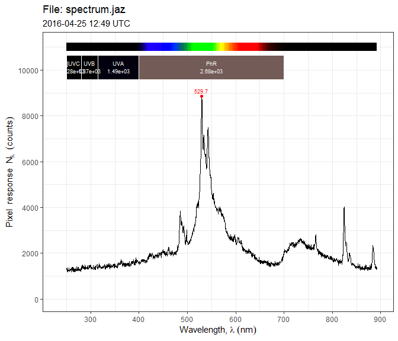

```r
autoplot(jazraw.spct)
```

The metadata stored in attributes can be accessed with functions. It is clear, that not all settings can be recovered from the file. However, we store the record will all the fields which would have been filled if the data had been acquired directly from R using package ‘ooacquire’.

```r
when_measured(jazraw.spct)
```

[output not shown]

```r
getInstrDesc(jazraw.spct)
```

```
## Data acquired with 'Jaz' s.n. JAZA3098
## grating 'NA', slit 'NA'
## diffuser 'unknown'
```

```r
getInstrSettings(jazraw.spct)
```

```
## integ. time (s): 0.748
## total time (s): 0.748
## counts @ peak (% of max):
```

#### Spectral energy irradiance

Reading an “Absolute Irradiance File” (sic) generated by Ocean Optics’ Jaz spectrometer results in a `source_spct` object. In this example, the light source measured was a `white’ fluorescent tube.

The first few lines of the file look like this:

```
Jaz Absolute Irradiance File
++++++++++++++++++++++++++++++++++++
Date: Tue Feb 03 09:44:41 2015
User: jaz
Dark Spectrum Present: Yes
Processed Spectrum Present: Yes
Spectrometers: JAZA1065
Integration Time (usec): 193000 (JAZA1065)
Spectra Averaged: 3 (JAZA1065)
Boxcar Smoothing: 5 (JAZA1065)
Correct for Electrical Dark: Yes (JAZA1065)
Strobe/Lamp Enabled: No (JAZA1065)
Correct for Detector Non-linearity: Yes (JAZA1065)
Correct for Stray Light: No (JAZA1065)
Number of Pixels in Processed Spectrum: 2048
Fiber (micron): 3900
Collection Area: 0.119459
Int. Sphere: No
>>>>>Begin Processed Spectral Data<<<<<
W   D   S   P
188.825226  0.000000    0.000000    0.000000
189.284851  0.000000    0.000000    0.000000
189.744415  -89.659378  -90.917900  -0.000000
190.203964  -106.165916 -96.419785  0.000000
...
```

```r
jaz.s.irrad.file <-
  system.file("extdata", "spectrum.JazIrrad",
              package = "photobiologyInOut", mustWork = TRUE)
jaz.spct <- read_oo_jazirrad(file = jaz.s.irrad.file)
jaz0.spct <- jaz.spct
jaz.spct <- trim_wl(jaz.spct, range = c(290, 800))
```

Plotting the spectrum.

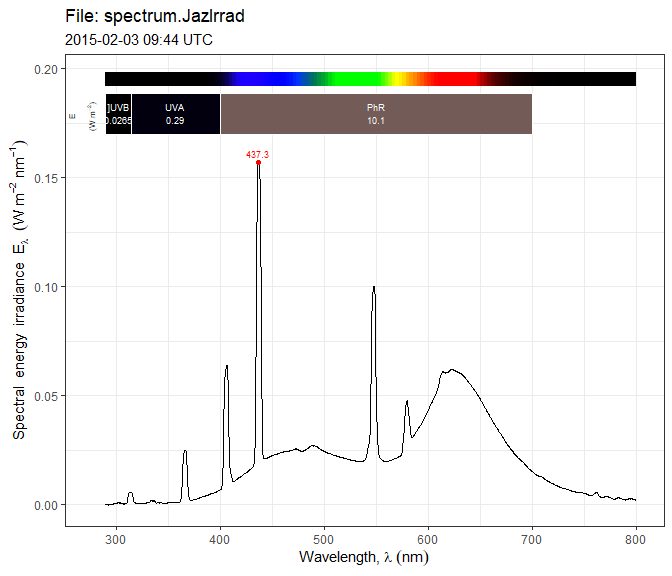

```r
autoplot(jaz.spct)
```

### Cleaning spectral data

We can see that the data have problems. We get a warning because the data include negative values for spectral irradiance. We will use some methods from package ‘photobiology’ to correct the problem. As the data are noisy we cannot just shift the scale so that the most negative value becomes zero. Neither can we replace all negative values with zeros, as this would create bias.

In the following code chunk we will use a region of the spectrum in which spectral irradiance is known to be equal to zero as reference to shift the scale zero. Afterwards we discard data ``known’’ to be zero, and for which the instrument calibration is not valid, and finally we plot the spectrum.

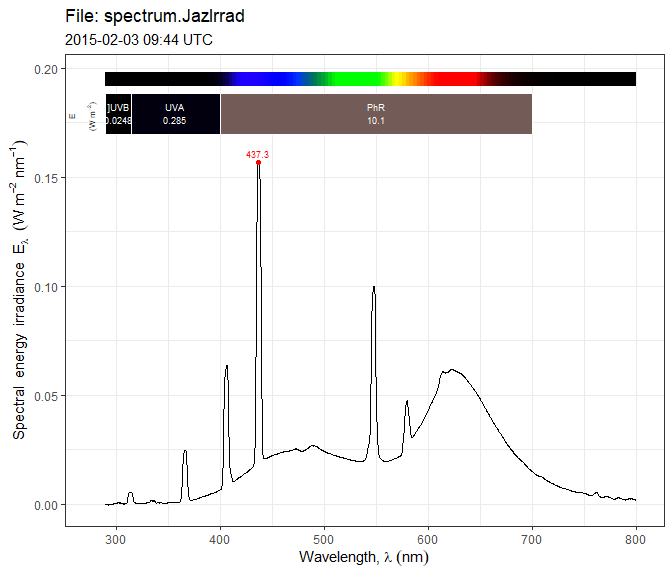

```r
jaz.spct <- fshift(jaz0.spct, range = c(255, 290), f = "mean")
jaz.spct <- trim_wl(jaz.spct, range = c(290, 800))
autoplot(jaz.spct)
```

We can next try to smooth the spectrum as it is very noisy outside the visible region.

```r
jaz.spct <- smooth_spct(jaz.spct)
```

```
## 314 possibly 'bad' values in smoothed spectral response
```

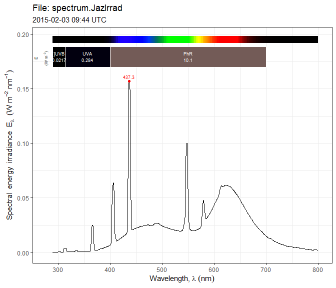

```r
autoplot(jaz.spct)
```

```r
e_irrad(jaz.spct, PAR())       # W m-2
```

```
##    E_PAR
## 10.16211
## attr(,"time.unit")
## [1] "second"
## attr(,"radiation.unit")
## [1] "total energy irradiance"
```

All in one statement.

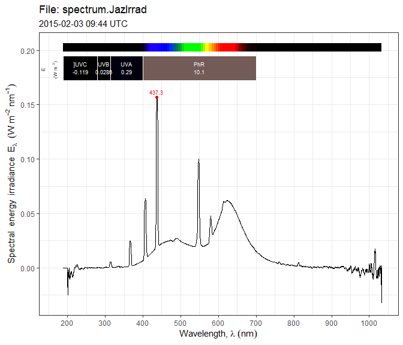

```r
autoplot(read_oo_jazirrad(file = jaz.s.irrad.file))
```

As above but limiting the wavelength range plotted.

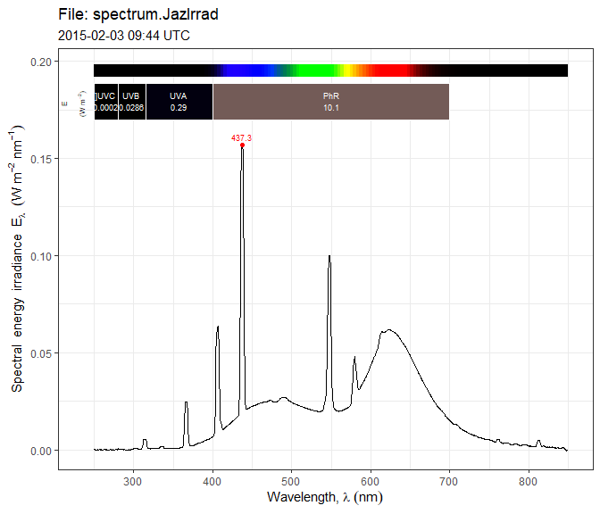

```r
autoplot(read_oo_jazirrad(file = jaz.s.irrad.file),
     range = c(250,850))
```

Adding our custom ``adaptive’’ smoothing.

```
## 714 possibly 'bad' values in smoothed spectral response
```

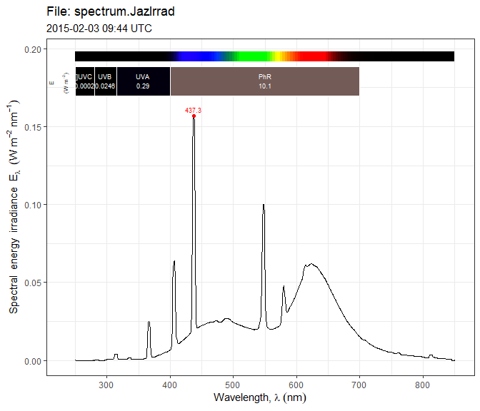

```r
autoplot(smooth_spct(read_oo_jazirrad(file = jaz.s.irrad.file)),
     range = c(250,850))
```

### Other array spectrometers from Ocean Optics

A file from an Ocean Optics’ Q6500 spectrometer, with data processed with the SpectraSuite software.

Format of the header is similar, but not identical. The first few lines of the file look like this:

```
SpectraSuite Data File
++++++++++++++++++++++++++++++++++++
Date: Mon May 06 15:13:40 CEST 2013
User: User
Dark Spectrum Present: Yes
Reference Spectrum Present: No
Number of Sampled Component Spectra: 1
Spectrometers: QEB1523
Integration Time (usec): 100000 (QEB1523)
Spectra Averaged: 1 (QEB1523)
Boxcar Smoothing: 0 (QEB1523)
Correct for Electrical Dark: No (QEB1523)
Strobe/Lamp Enabled: No (QEB1523)
Correct for Detector Non-linearity: No (QEB1523)
Correct for Stray Light: Yes (QEB1523)
Number of Pixels in Processed Spectrum: 1044
>>>>>Begin Processed Spectral Data<<<<<
199.08  0.0000E00
199.89  0.0000E00
200.70  0.0000E00
...
```

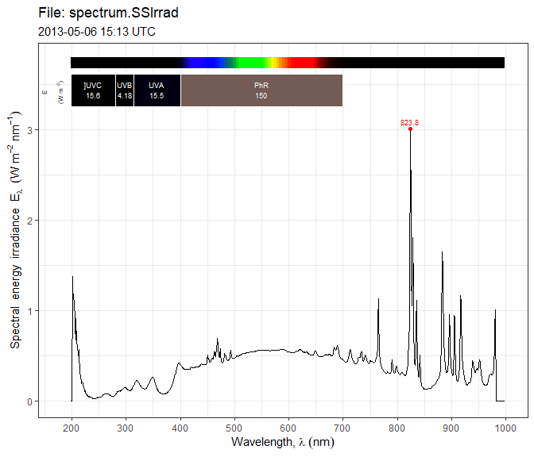

```r
q.raw.file <-
  system.file("extdata", "spectrum.SSIrrad",
              package = "photobiologyInOut", mustWork = TRUE)
autoplot(read_oo_ssirrad(file = q.raw.file))
```

### Array spectrometers from Wasatch Photonics

Enlighten can save spectral data in a variety of file formats. The function `read_wasatch_csv()` reads CSV files with spectral data in columns. It is designed so that it can read any variation of this file format. In Enlighten it is possible to select which columns are included in the file so their number can vary. However, the header is rich in information and this allows in many but not all cases to guess based on the “Technique” used in Enlighten the type of data being imported. This means that in some cases the user needs to pass an argument to parameter `s.qty`. This is also the case when the column to be extracted is not that with heading “Processed” in the CSV file. The metadata is as for Ocean Insight/Ocean Optics spectrometers copied to attributes in the returned object.

Format of the header is simple and rather easy to parse. The header of the file and the first few lines look like this:

```
ENLIGHTEN Version,2.2.7
Measurement ID,20211003-134004-612972-WP-00591
Serial Number,WP-00591
Model,WP-UV-VIS-C-S-25
Label,13:40:04 WP-00591
Declared Match,
Declared Score,0
Scan Averaging,1
Boxcar,0
Technique,Scope
Baseline Correction Algo,
ROI Pixel Start,0
ROI Pixel End,1023
Slit Width,25
Vignetted,False
Interpolated,False
Raman Intensity Corrected,False
Deconvolved,False
Integration Time,60
Timestamp,2021-10-03 13:40:04.612972
Note,Dark substracted
Temperature,-15.327480412352088
CCD C0,247.9385986328125
CCD C1,0.5131465792655945
CCD C2,-0.00012270470324438065
CCD C3,7.728250039917839e-08
CCD Offset,0
CCD Gain,1.9
Laser Wavelength,0.0
Laser Enable,False
Laser Power,100
Laser Temperature,0
Pixel Count,1024

Pixel,Wavelength,Processed
0,247.94,175.00
1,248.45,178.00
```

```r
file.name <-
    system.file("extdata", "enlighten-wasatch-scope.csv",
                package = "photobiologyInOut", mustWork = TRUE)

wasatch.raw.spct <-
    read_wasatch_csv(file = file.name, extra.cols = "drop")
```

```r
summary(wasatch.raw.spct)
```

```
## Summary of raw_spct [1,024 x 2] object: wasatch.raw.spct
## Wavelength range 247.94-709.67 nm, step 0.43-0.52 nm
## Label:  File: enlighten-wasatch-scope.csv
## Measured on  2021-10-03 13:40:04.612972  UTC
## Data acquired with 'WP-UV-VIS-C-S-25' s.n. WP-00591
## grating 'default', slit '25'
## diffuser 'unknown'
## integ. time (s): 0.06
## total time (s): 0.06
## counts @ peak (% of max): NAVariables:
##  w.length: Wavelength [nm]
##  counts: Raw detector counts [number]
## --
##     w.length         counts
##  Min.   :247.9   Min.   :  173
##  1st Qu.:372.4   1st Qu.: 1604
##  Median :487.6   Median :27621
##  Mean   :484.8   Mean   :25832
##  3rd Qu.:598.8   3rd Qu.:43249
##  Max.   :709.7   Max.   :61251
```

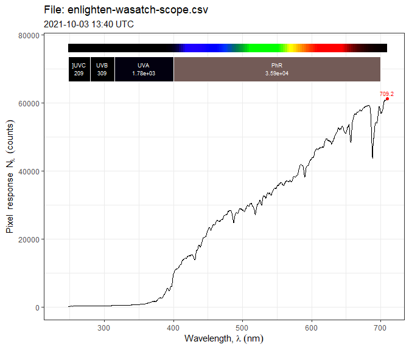

```r
autoplot(wasatch.raw.spct)
```

### Array spectrometers from Avantes

Avantes’ two column .csv files can also be imported.

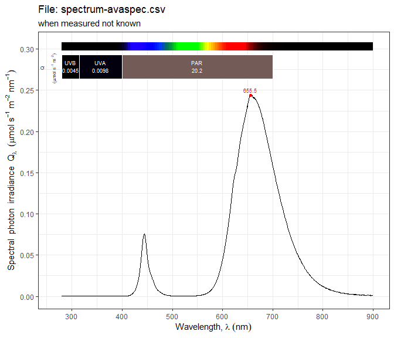

```r
ava.raw.file <-
  system.file("extdata", "spectrum-avaspec.csv",
              package = "photobiologyInOut", mustWork = TRUE)
autoplot(read_avaspec_csv(file = ava.raw.file),
     range = c(280, 900), unit.out = "photon")
```

### Scanning spectrometer from Macam

Macam’s single column DTA files can also be imported.

The first few lines of the file look like this with all data in a single column with alternate rows for wavelengths (in nm) and irradiances, and a very terse header:

```
@19/5/1997
@17:44:58
#No Title
 2.5000000000E+02
 0.0000000000E+00
 2.5100000000E+02
 0.0000000000E+00
 2.5200000000E+02
 0.0000000000E+00
...
```

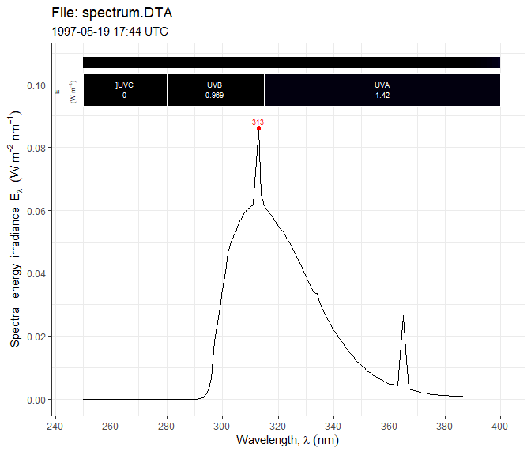

```r
macam.raw.file <-
  system.file("extdata", "spectrum.DTA",
              package = "photobiologyInOut", mustWork = TRUE)
autoplot(read_macam_dta(file = macam.raw.file))
```

### LI-180 array dector spectrometer from LI-COR

The LI-COR LI-180 is a portable, self-contained instrument, with relatively low spectral resolution. This instrument measures spectral irradiance in the range 380 nm to 780 nm. There is only one hardware configuration but firmware updates have been released.

The top of the file we will read looks like this:

```
Model Name  LI-180
Serial Number   A18M0157
Time    2021/03/02_09:24:26
PPFD    129.879440
PFD 171.178452
PFD-UV  2.336031
PFD-B   33.417435
PFD-G   46.992531
PFD-R   49.469433
PFD-FR  38.963074
Custom1(655~665nm)  5.057602
Custom2(725~735nm)  4.957998
Custom3(650~670nm)  10.137251
Custom4(720~740nm)  9.965228
UV% 1.364676
B%  19.521980
G%  27.452354
R%  28.899324
FR% 22.761662
Custom1%    2.954579
Custom2%    2.896391
Custom3%    5.922037
Custom4%    5.821544
R:B 1.480348
R:FR    1.269649
R:G 1.052708
B:G 0.711122
UV:B    0.069905
UV:FR   0.059955
B:G:R   0.000000
B:R:FR  0.000000
UV:B:G:R:FR 0.000000
Ratio1(Custom1:Custom2) 1.020090
Ratio2(Custom3:Custom4) 1.017262
Ratio3  0.000000
Ratio4  0.000000
LambdaP 495.000000
LambdaPV    106.211479
LambdaD 554.000000
LUX 7366.741699
IRR 35.163498
fc  684.641418
I-Time  92.000000
380nm   27.503876
381nm   27.968113
382nm   28.452974
383nm   28.665405
...
```

And the footer containing chromaticity data:

```
...
778nm   82.020149
779nm   82.078781
780nm   82.042412
CCT 5465.000000
Duv 0.004667
x   0.333318
y   0.351069
u'  0.203671
v'  0.482666
deltax  0.000063
deltay  0.009303
deltau' -0.003491
deltav' 0.004648
Purity  5.337072
CRI 98.779282
R1  98.665459
R2  99.470703
R3  98.974945
R4  98.248100
R5  98.830368
R6  99.473335
R7  98.902351
R8  97.668961
R9  94.101921
R10 99.232346
R11 98.246521
R12 99.336227
R13 98.899147
R14 99.324699
R15 97.831963
```

```r
licor_espd.file <-
  system.file("extdata", "LI-180-irradiance.txt",
              package = "photobiologyInOut", mustWork = TRUE)
li180.spct <- read_li180_txt(file = licor_espd.file)
```

In all cases as much information as possible is decoded, and the data file headers are preserved as comments in the source.spct objects.

```r
li180.spct
```

```
## Object: source_spct [401 x 2]
## Wavelength range 380-780 nm, step 1 nm
## Label: File: LI-180-irradiance.txt
## Measured on 2021-03-02 09:24:26 UTC
## Variables:
##  w.length: Wavelength [nm]
##  s.e.irrad: Spectral energy irradiance [W m-2 nm-1]
## --
## # A tibble: 401 × 2
##   w.length s.e.irrad
##      <dbl>     <dbl>
## 1      380    0.0275
## 2      381    0.0280
## 3      382    0.0285
## # ℹ 398 more rows
```

```r
cat(comment(li180.spct))
```

```
## LICOR LI-180 file 'LI-180-irradiance.txt' imported on 2025-09-24 17:53:26.522601 UTC
## Model Name   LI-180
## Serial Number    A18M0157
## Time 2021/03/02_09:24:26
## PPFD 129.879440
## PFD  171.178452
## PFD-UV   2.336031
## PFD-B    33.417435
## PFD-G    46.992531
## PFD-R    49.469433
## PFD-FR   38.963074
## Custom1(655~665nm)   5.057602
## Custom2(725~735nm)   4.957998
## Custom3(650~670nm)   10.137251
## Custom4(720~740nm)   9.965228
## UV%  1.364676
## B%   19.521980
## G%   27.452354
## R%   28.899324
## FR%  22.761662
## Custom1% 2.954579
## Custom2% 2.896391
## Custom3% 5.922037
## Custom4% 5.821544
## R:B  1.480348
## R:FR 1.269649
## R:G  1.052708
## B:G  0.711122
## UV:B 0.069905
## UV:FR    0.059955
## B:G:R    0.000000
## B:R:FR   0.000000
## UV:B:G:R:FR  0.000000
## Ratio1(Custom1:Custom2)  1.020090
## Ratio2(Custom3:Custom4)  1.017262
## Ratio3   0.000000
## Ratio4   0.000000
## LambdaP  495.000000
## LambdaPV 106.211479
## LambdaD  554.000000
## LUX  7366.741699
## IRR  35.163498
## fc   684.641418
## I-Time   92.000000
```

```r
getInstrDesc(li180.spct)
```

```
## Data acquired with 'LI-180' s.n. A18M0157
## grating 'NA', slit 'NA'
## diffuser 'unknown'
```

```r
getInstrSettings(li180.spct)
```

```
## integ. time (s): 0.092
## total time (s): NA
## counts @ peak (% of max): NA
```

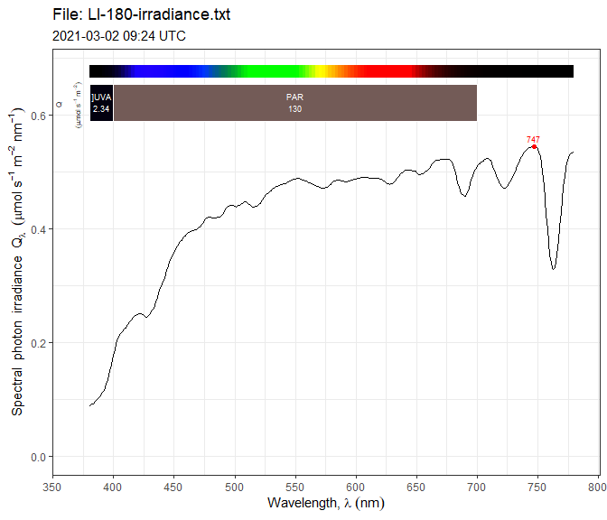

```r
autoplot(li180.spct, unit.out = "photon")
```

### LI-1800 scanning spectrometer from LI-COR

Spectral photon irradiance output files generated by LI-COR’s PC1800 program for the LI-1800 spectroradiometer. These files have a relatively detailed header, but it lacks year information. Files can contain either energy or photon based spectral irradiances, and this is signalled in the header. In this example photon (= quantum) spectral irradiance is returned. The first few lines of the file look like this:

```
"FILE:FL2"
"REM: TLD 36W/865       (QNTM)"
"LIMS: 300- 900NM"
"INT:  1NM"
"DATE:08/23 16:32"
"MIN:  300NM  1.518E-04"
"MAX:  546NM  7.491E-01"
 300  1.518E-04
 301  3.355E-04
 302  2.197E-04
 303  3.240E-04
...
```

Function `read_licor_prn` will automatically detect whether the data is energy or photon based. In all cases as much metadata information as possible is decoded, and the data file headers are preserved as comments in the source.spct objects. **The missing information for year is set to zero in the `when.measured` attribute, with month, day, hours and minutes as decoded from the header. The time zone defaults to UTC and will need in general to be passed as an argument to `tz` in the function call.**

```r
licor.file <-
  system.file("extdata", "spectrum.PRN",
              package = "photobiologyInOut", mustWork = TRUE)
licor.spct <- read_licor_prn(file = licor.file, tz = "Europe/Helsinki")
```

Even when using to correct argument for `tz` the time will still default to UTC when the spectrum is printed or plotted, but this time expressed in UTC may still be shifted from the correct time in the time zone where measurements were acquired as without year information it is impossible to adjust for daylight saving time and other shifts in local times that have changed over the years as a result of changes in legislation.

```r
licor.spct
```

```
## Object: source_spct [601 x 2]
## Wavelength range 300-900 nm, step 1 nm
## Label: File: spectrum.PRN
## Measured on 0-08-23 14:52:11 UTC
## Variables:
##  w.length: Wavelength [nm]
##  s.q.irrad: Spectral photon irradiance [mol s-1 m-2 nm-1]
## --
## # A tibble: 601 × 2
##   w.length s.q.irrad
##      <dbl>     <dbl>
## 1      300  1.52e-10
## 2      301  3.36e-10
## 3      302  2.20e-10
## # ℹ 598 more rows
```

```r
cat(comment(licor.spct))
```

```
## LICOR LI-1800 file 'spectrum.PRN' imported on 2025-09-24 17:53:27.135409 UTC
## "FILE:FL2"
## "REM: TLD 36W/865       (QNTM)"
## "LIMS: 300- 900NM"
## "INT:  1NM"
## "DATE:08/23 16:32"
## "MIN:  300NM  1.518E-04"
## "MAX:  546NM  7.491E-01"
```

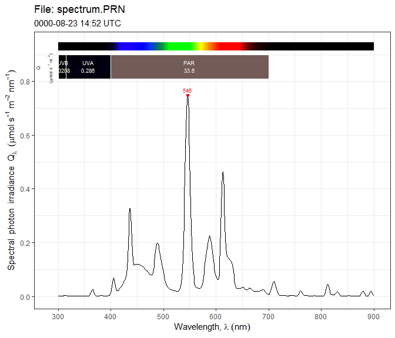

```r
autoplot(licor.spct, unit.out = "photon")
```

It is also possible to use the same function to import reflectance, and transmittance spectra acquired by the LI-1800.

And a spectral reflectance output file generated by LI-COR’s PC1800 program for the LI-1800 spectroradiometer is used next.

The first few lines of the file look like this:

```
"FILE:RGD1"
"REM: REFL GREEN AD 1 "
"LIMS: 350- 800NM"
"INT:  2NM"
"DATE:05/30 13:50"
"MIN:  358NM  4.628E-02"
"MAX:  776NM  4.693E-01"
 350  5.135E-02
 352  4.713E-02
 354  5.324E-02
 356  4.740E-02
...
```

Function `read_licor_prn` cannot automatically detect the spectral quantity in the file, and when the irradiance default is not correct, users need to override it with an explicit argument for parameter `s.qty`.

```r
licor.file <-
  system.file("extdata", "reflectance.PRN",
              package = "photobiologyInOut", mustWork = TRUE)
licor.spct <- read_licor_prn(file = licor.file, s.qty = "Rfr")
```

In all cases as much information as possible is decoded, and the data file headers are preserved as comments in the source.spct objects.

```r
licor.spct
```

```
## Object: reflector_spct [226 x 2]
## Wavelength range 350-800 nm, step 2 nm
## Label: File: reflectance.PRN
## Measured on 0-05-30 13:50:00 UTC
## Variables:
##  w.length: Wavelength [nm]
##  Rfr: Total spectral reflectance [/1]
## --
## # A tibble: 226 × 2
##   w.length    Rfr
##      <dbl>  <dbl>
## 1      350 0.0514
## 2      352 0.0471
## 3      354 0.0532
## # ℹ 223 more rows
```

```r
cat(comment(licor.spct))
```

```
## LICOR LI-1800 file 'reflectance.PRN' imported on 2025-09-24 17:53:27.719927 UTC
## "FILE:RGD1"
## "REM: REFL GREEN AD 1 "
## "LIMS: 350- 800NM"
## "INT:  2NM"
## "DATE:05/30 13:50"
## "MIN:  358NM  4.628E-02"
## "MAX:  776NM  4.693E-01"
```

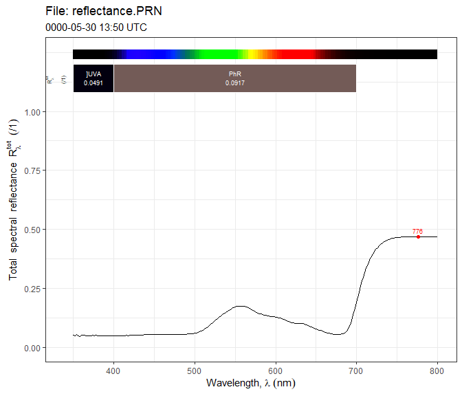

```r
autoplot(licor.spct)
```

### The SpectraPen spectroradiometer from PSI

This all-in-one spectroradiometer measures spectral irradiance, and returns the data in a `.CSV` file with one column per spectrum. The data are returned expressed in energy or photon based units.

The first few lines of a data block look like this:

```
Irradiance   [µW/cm2/nm],
Time,11/10/2022 7:08:01 PM,11/10/2022 7:08:05 PM,11/10/2022 7:08:10 PM,11/10/2022 7:08:32 PM,11/10/2022 7:08:36 PM,11/10/2022 7:08:42 PM,
Index,13,14,15,16,17,18,
Name,,,,,,,
GPS,,,,,,,
[nm],
327.1,3.733005E+000,3.711488E+000,3.914620E+000,9.741472E+000,9.176950E+000,1.050528E+001
329,3.557857E+000,3.256521E+000,3.686638E+000,8.320147E+000,8.764947E+000,8.995773E+000
330.8,3.250507E+000,2.988691E+000,3.100541E+000,7.933364E+000,8.187113E+000,8.819886E+000
...
```

or

```
Irradiance   [µE/m2/s/nm],

Time,11/10/2022 7:08:01 PM,11/10/2022 7:08:05 PM,11/10/2022 7:08:10 PM,11/10/2022 7:08:32 PM,11/10/2022 7:08:36 PM,11/10/2022 7:08:42 PM,
Index,13,14,15,16,17,18,
Name,,,,,,,
GPS,,,,,,,
[nm],
327.1,1.020666E-001,1.014783E-001,1.070323E-001,2.663483E-001,2.509133E-001,2.872321E-001
329,9.783817E-002,8.955168E-002,1.013796E-001,2.287973E-001,2.410289E-001,2.473764E-001
330.8,8.989830E-002,8.265734E-002,8.575075E-002,2.194107E-001,2.264286E-001,2.439290E-001
```

```r
  file.name <-
    system.file("extdata", "spectrum-psi-spectrapen-SP.csv",
                package = "photobiologyInOut", mustWork = TRUE)
  psi.mspct <- read_spectrapen_csv(file = file.name,
                                  tz = "UTC")
  summary(psi.mspct)
```

```
## Summary of source_mspct [6 x 1] object: psi.mspct
## # A tibble: 6 × 8
##   spct.idx class       dim    w.length.min w.length.max
##   <chr>    <chr>       <chr>         <dbl>        <dbl>
## 1 spct.13  source_spct [256 …         327.          793
## 2 spct.14  source_spct [256 …         327.          793
## 3 spct.15  source_spct [256 …         327.          793
## # ℹ 3 more rows
## # ℹ 3 more variables: colnames <list>,
## #   multiple.wl <dbl>, time.unit <Duration>
```

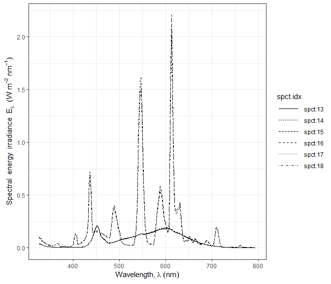

```r
  autoplot(psi.mspct, annotations = "")
```

```r
summary(psi.mspct[["spct.14"]])
```

```
## Summary of source_spct [256 x 2] object: anonymous
## Wavelength range 327.1-793 nm, step 1.7-1.9 nm
## Label:  spct.14
## Measured on  2022-10-11 19:08:05  UTC
## Variables:
##  w.length: Wavelength [nm]
##  s.e.irrad: Spectral energy irradiance [W m-2 nm-1]
## --
##     w.length       s.e.irrad
##  Min.   :327.1   Min.   :-0.0008146
##  1st Qu.:447.1   1st Qu.: 0.0049111
##  Median :565.5   Median : 0.0453238
##  Mean   :563.7   Mean   : 0.0630290
##  3rd Qu.:681.1   3rd Qu.: 0.1137516
##  Max.   :793.0   Max.   : 0.2072932
```

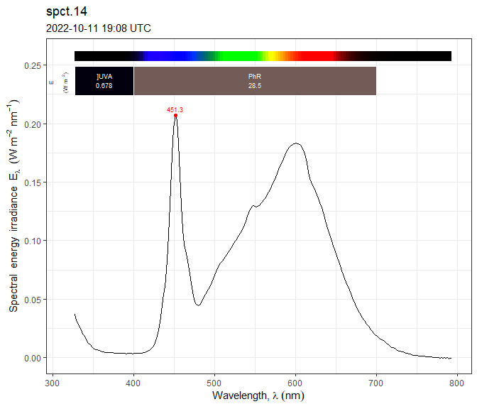

```r
autoplot(psi.mspct[["spct.14"]])
```

**Note:** It is clear from the figure above that this spectrometer suffers badly from straylight in the UV-A region, and readings at wavelengths shorter than 400 nm in the presence of stronger radiation at longer wavelengths are to be discarded.

### The leaf spectrometer from CID Bio-Science

This all-in-one spectrometer measures spectral reflectance, spectral transmittance or spectral absorbance of plant leaves or in fact any thin film. There is a single configuration available and being based on a microcontroller this instrument is used autonomously and spectral data saved internally can be exported as CSV files.

Reflectance and transmittance generate a single spectrum per measurement while absorbance generates three: spectral absorbance, spectral reflectance and spectral transmittance. The last two are needed to compute absorbance, and, wisely, they are also returned. In the case of absorbance measurements it is possible to import the data into an `object_spct` containing variables `Rfr` and `Tfr` or as separate objects.

```r
  file.name <-
    system.file("extdata", "cid-spectravue-Rpc-Measurements.csv",
                package = "photobiologyInOut", mustWork = TRUE)
  cid_Rpc.spct <- read_cid_spectravue_csv(file = file.name)
```

```
## Found 9/2048 off-range 'Rfr' values [0.00..32.42] instead of  [0..1]
```

```r
  summary(cid_Rpc.spct)
```

```
## Summary of reflector_spct [1,235 x 2] object: cid_Rpc.spct
## Wavelength range 380.30945-1099.8846 nm, step 0.5594482-0.6019592 nm
## Label:   Reflectance.
## Measured on  2022-03-08 15:02:47  UTC
## Variables:
##  w.length: Wavelength [nm]
##  Rfr: Total spectral reflectance [/1]
## --
##     w.length           Rfr
##  Min.   : 380.3   Min.   :0.0258
##  1st Qu.: 564.8   1st Qu.:0.2392
##  Median : 746.7   Median :0.4474
##  Mean   : 744.5   Mean   :0.3626
##  3rd Qu.: 925.2   3rd Qu.:0.4935
##  Max.   :1099.9   Max.   :0.5188
```

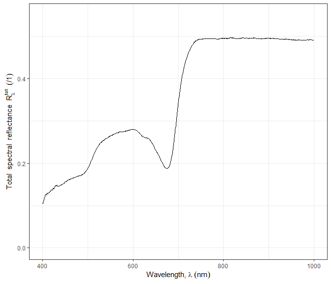

```r
  autoplot(smooth_spct(cid_Rpc.spct, method = "supsmu"),
           range = c(400, 1000), annotations = "") %+%
    ylim(0, 0.55)
```